# TargetCNV-ML: Reporte de Transferencia Filogenética y Concordancia CNV

GBM en S. stellatiglandulosum — F1: 0.409 | ROC-AUC: 0.914 | Exactitud: 72.50% | Exactitud Bal.: 84.81% | Sensibilidad: 100.00% | Especificidad: 69.61% | Precisión: 25.68% | FDR: 74.32%

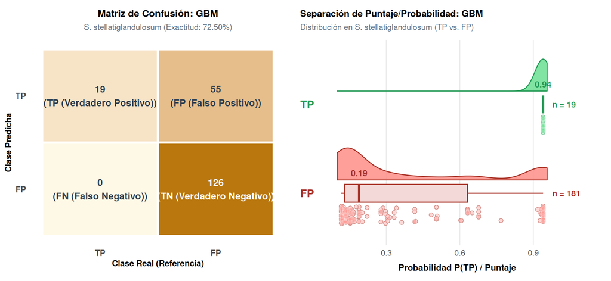

**Youden_pct_identity**

Youden_pct_identity en S. stellatiglandulosum — F1: 0.494 | ROC-AUC: 0.913 | Exactitud: 80.50% | Exactitud Bal.: 89.23% | Sensibilidad: 100.00% | Especificidad: 78.45% | Precisión: 32.76% | FDR: 67.24%

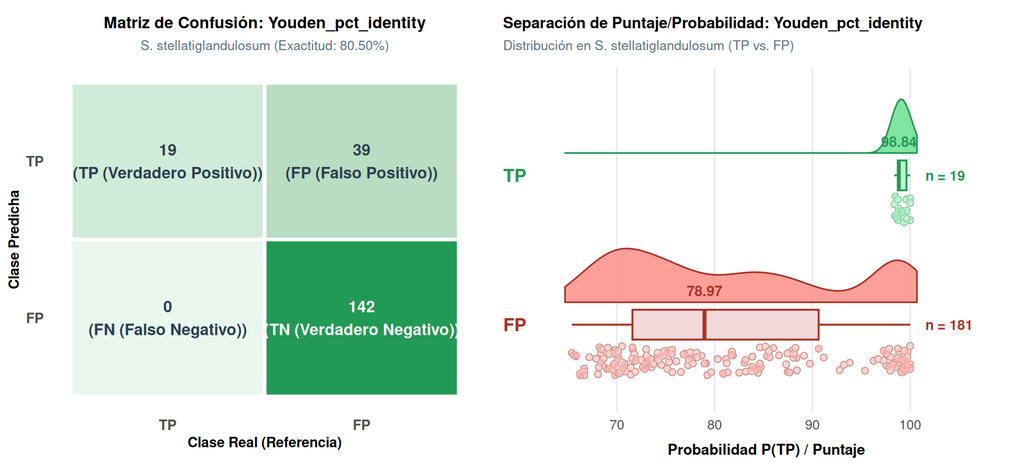

**Youden_score**

Youden_score en S. stellatiglandulosum — F1: 0.404 | ROC-AUC: 0.913 | Exactitud: 72.00% | Exactitud Bal.: 84.53% | Sensibilidad: 100.00% | Especificidad: 69.06% | Precisión: 25.33% | FDR: 74.67%

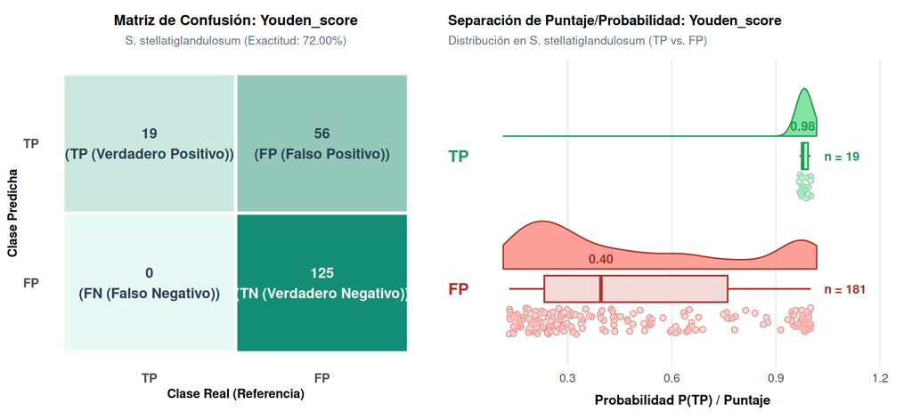

**Youden_wscore**

Youden_wscore en S. stellatiglandulosum — F1: 0.409 | ROC-AUC: 0.913 | Exactitud: 72.50% | Exactitud Bal.: 84.81% | Sensibilidad: 100.00% | Especificidad: 69.61% | Precisión: 25.68% | FDR: 74.32%

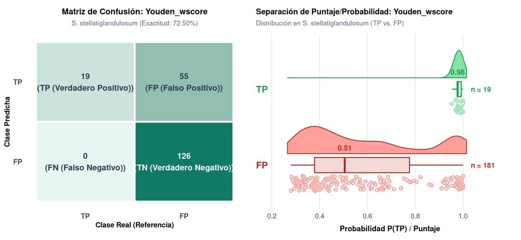

**NaiveBayes**

NaiveBayes en S. stellatiglandulosum — F1: 0.392 | ROC-AUC: 0.913 | Exactitud: 70.50% | Exactitud Bal.: 83.70% | Sensibilidad: 100.00% | Especificidad: 67.40% | Precisión: 24.36% | FDR: 75.64%

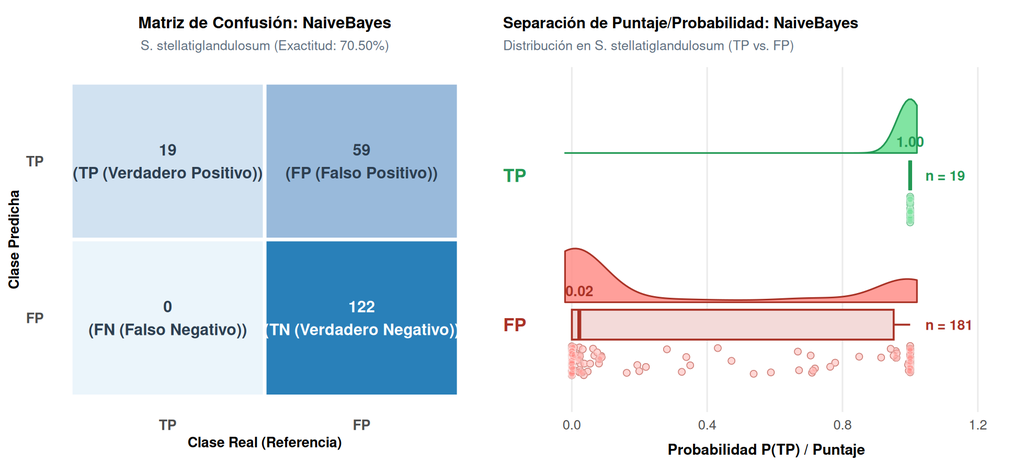

**SVM_Polinomial**

SVM_Polinomial en S. stellatiglandulosum — F1: 0.432 | ROC-AUC: 0.912 | Exactitud: 75.00% | Exactitud Bal.: 86.19% | Sensibilidad: 100.00% | Especificidad: 72.38% | Precisión: 27.54% | FDR: 72.46%

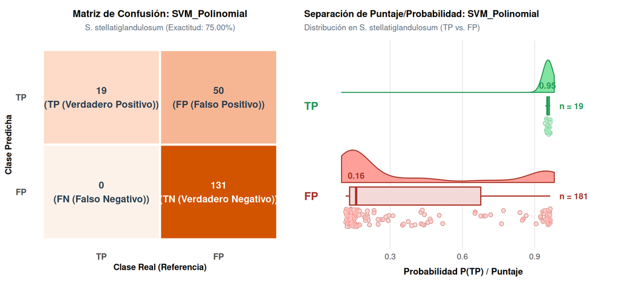

**Ensamble_Stacking**

Ensamble_Stacking en S. stellatiglandulosum — F1: 0.418 | ROC-AUC: 0.912 | Exactitud: 73.50% | Exactitud Bal.: 85.36% | Sensibilidad: 100.00% | Especificidad: 70.72% | Precisión: 26.39% | FDR: 73.61%

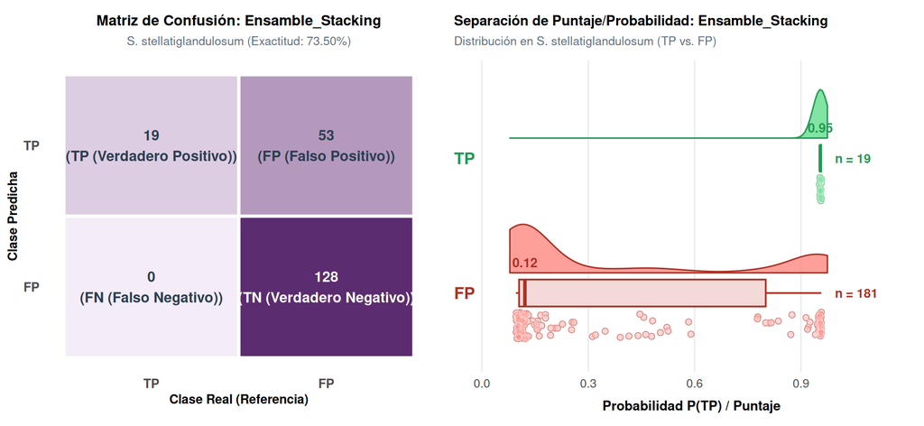

**Red_Neuronal**

Red_Neuronal en S. stellatiglandulosum — F1: 0.392 | ROC-AUC: 0.912 | Exactitud: 70.50% | Exactitud Bal.: 83.70% | Sensibilidad: 100.00% | Especificidad: 67.40% | Precisión: 24.36% | FDR: 75.64%

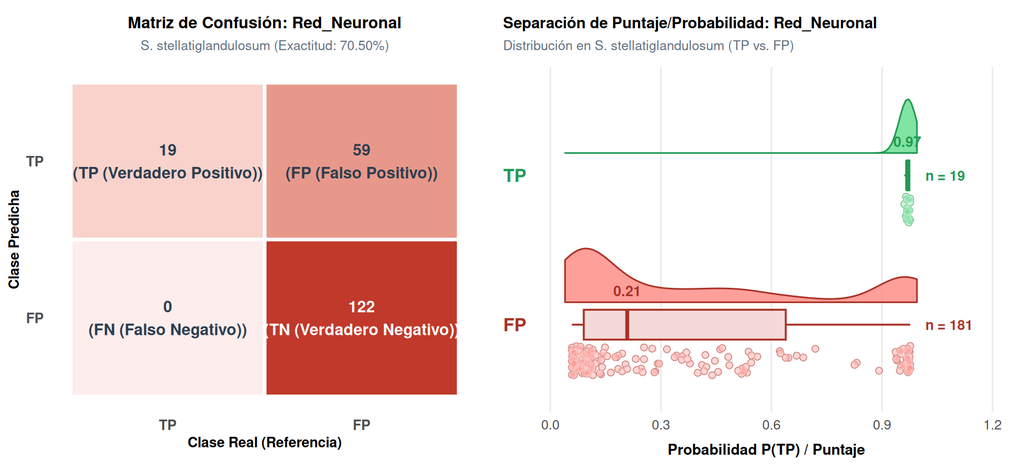

**ElasticNet**

ElasticNet en S. stellatiglandulosum — F1: 0.369 | ROC-AUC: 0.912 | Exactitud: 67.50% | Exactitud Bal.: 82.04% | Sensibilidad: 100.00% | Especificidad: 64.09% | Precisión: 22.62% | FDR: 77.38%

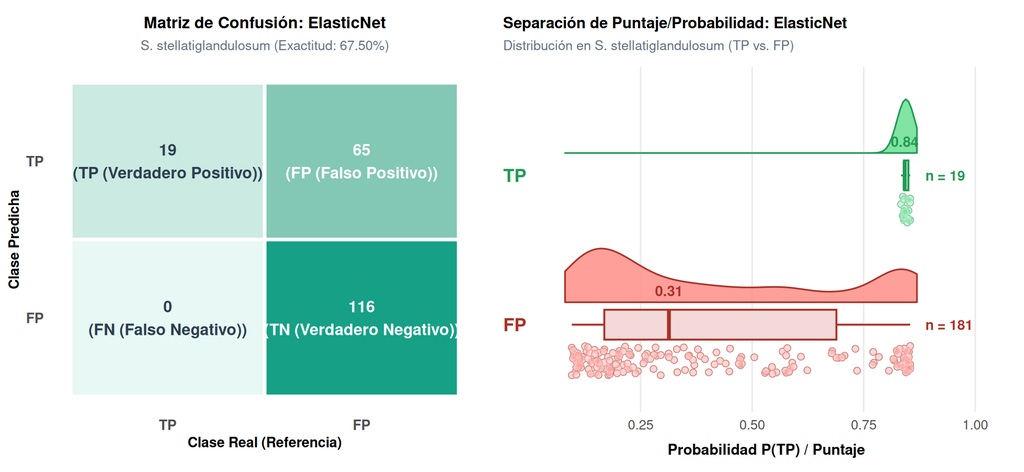

**SVM_Lineal**

SVM_Lineal en S. stellatiglandulosum — F1: 0.396 | ROC-AUC: 0.912 | Exactitud: 71.00% | Exactitud Bal.: 83.98% | Sensibilidad: 100.00% | Especificidad: 67.96% | Precisión: 24.68% | FDR: 75.32%

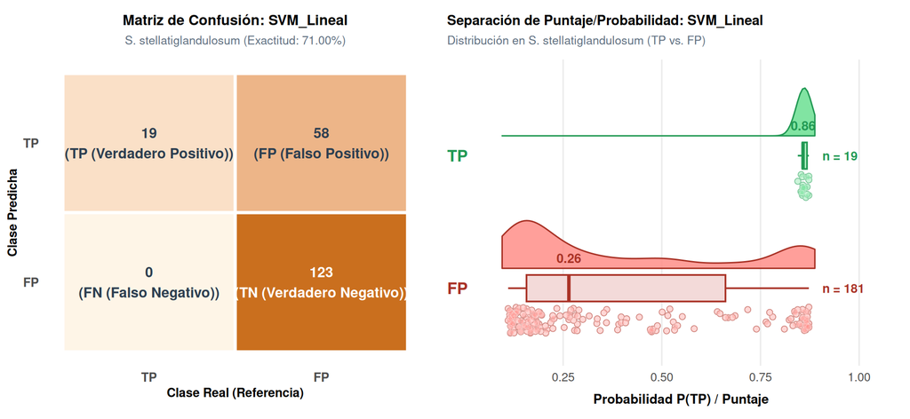

**Red_Neuronal_Bag**

Red_Neuronal_Bag en S. stellatiglandulosum — F1: 0.376 | ROC-AUC: 0.912 | Exactitud: 68.50% | Exactitud Bal.: 82.60% | Sensibilidad: 100.00% | Especificidad: 65.19% | Precisión: 23.17% | FDR: 76.83%

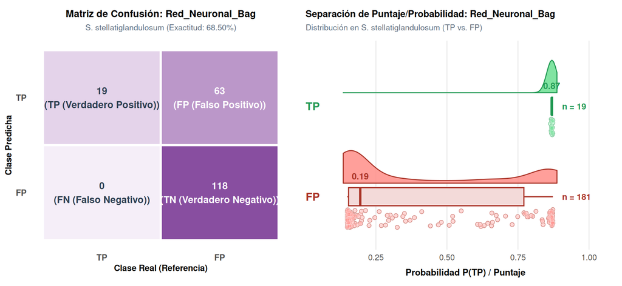

**MLP_Regularizado**

MLP_Regularizado en S. stellatiglandulosum — F1: 0.376 | ROC-AUC: 0.912 | Exactitud: 68.50% | Exactitud Bal.: 82.60% | Sensibilidad: 100.00% | Especificidad: 65.19% | Precisión: 23.17% | FDR: 76.83%

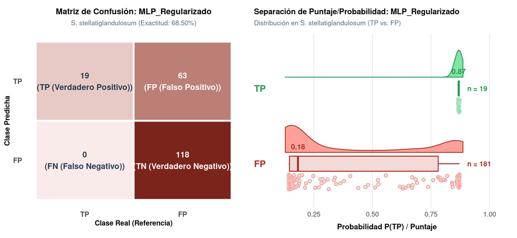

**MLP**

MLP en S. stellatiglandulosum — F1: 0.437 | ROC-AUC: 0.912 | Exactitud: 75.50% | Exactitud Bal.: 86.46% | Sensibilidad: 100.00% | Especificidad: 72.93% | Precisión: 27.94% | FDR: 72.06%

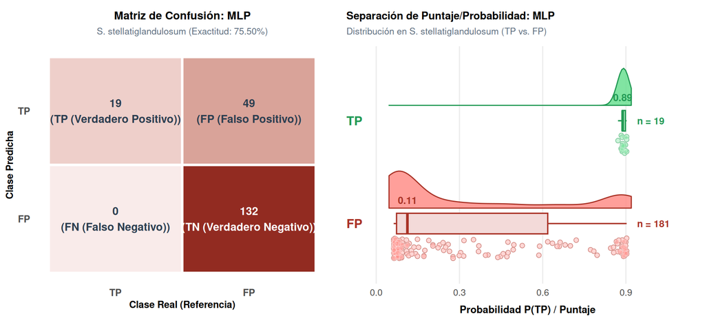

**LDA**

LDA en S. stellatiglandulosum — F1: 0.413 | ROC-AUC: 0.912 | Exactitud: 73.00% | Exactitud Bal.: 85.08% | Sensibilidad: 100.00% | Especificidad: 70.17% | Precisión: 26.03% | FDR: 73.97%

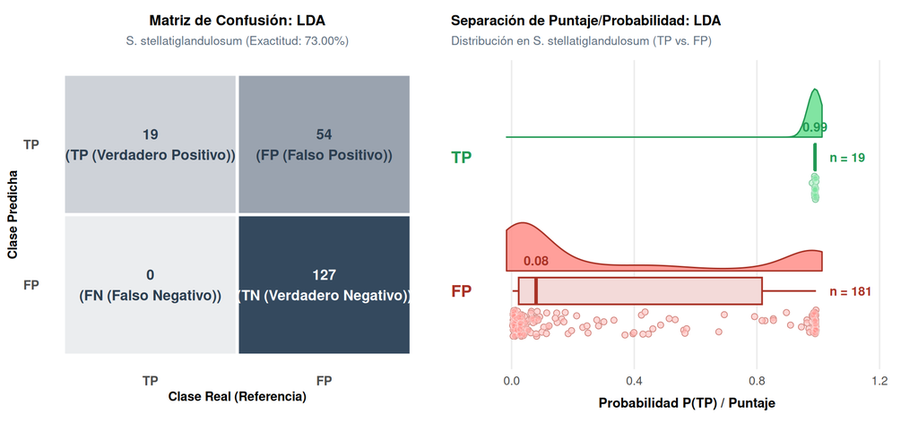

**Bagging_Arboles**

Bagging_Arboles en S. stellatiglandulosum — F1: 0.396 | ROC-AUC: 0.912 | Exactitud: 71.00% | Exactitud Bal.: 83.98% | Sensibilidad: 100.00% | Especificidad: 67.96% | Precisión: 24.68% | FDR: 75.32%

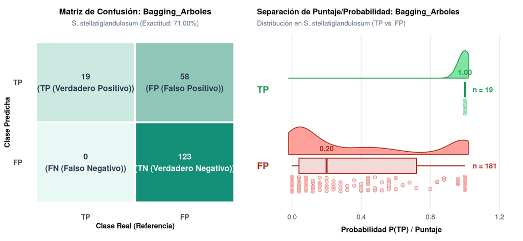

**QDA**

QDA en S. stellatiglandulosum — F1: 0.400 | ROC-AUC: 0.911 | Exactitud: 71.50% | Exactitud Bal.: 84.25% | Sensibilidad: 100.00% | Especificidad: 68.51% | Precisión: 25.00% | FDR: 75.00%

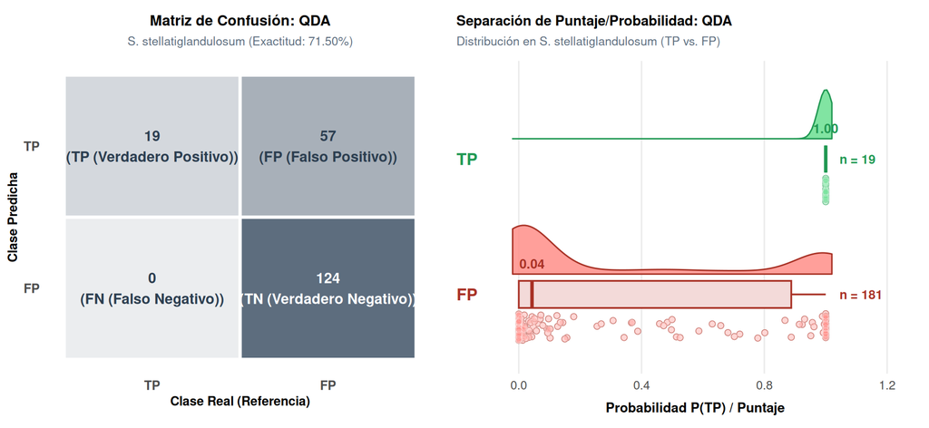

**XGBoost**

XGBoost en S. stellatiglandulosum — F1: 0.396 | ROC-AUC: 0.903 | Exactitud: 71.00% | Exactitud Bal.: 83.98% | Sensibilidad: 100.00% | Especificidad: 67.96% | Precisión: 24.68% | FDR: 75.32%

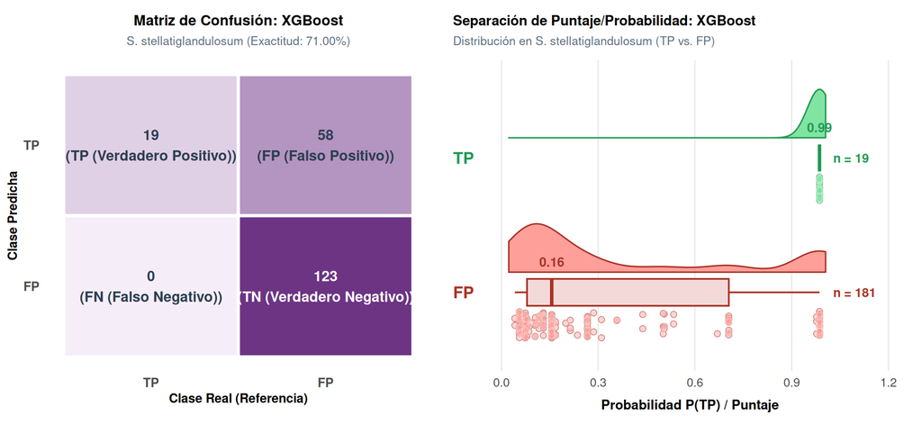

**RandomForest**

RandomForest en S. stellatiglandulosum — F1: 0.380 | ROC-AUC: 0.901 | Exactitud: 69.00% | Exactitud Bal.: 82.87% | Sensibilidad: 100.00% | Especificidad: 65.75% | Precisión: 23.46% | FDR: 76.54%

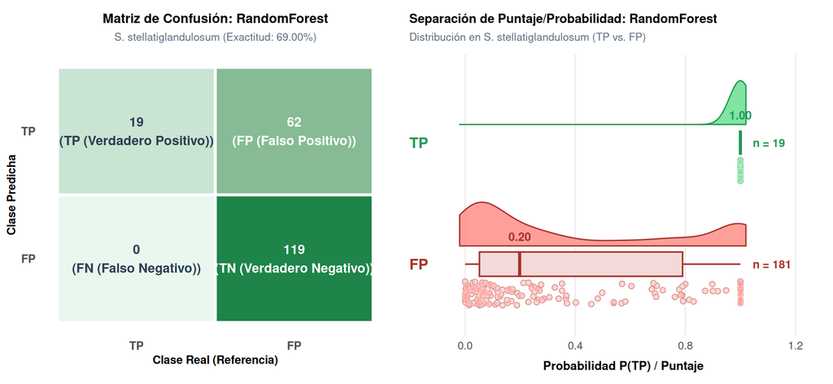

**Weighted_Heuristic**

Weighted_Heuristic en S. stellatiglandulosum — F1: 0.413 | ROC-AUC: 0.898 | Exactitud: 73.00% | Exactitud Bal.: 85.08% | Sensibilidad: 100.00% | Especificidad: 70.17% | Precisión: 26.03% | FDR: 73.97%

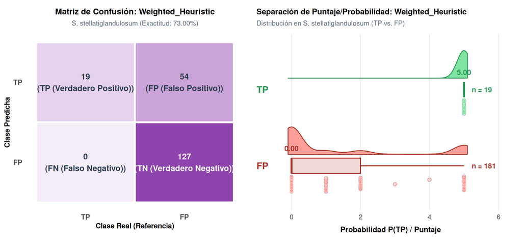

**Consenso_7_Modelos**

Consenso_7_Modelos en S. stellatiglandulosum — F1: 0.392 | ROC-AUC: 0.898 | Exactitud: 70.50% | Exactitud Bal.: 83.70% | Sensibilidad: 100.00% | Especificidad: 67.40% | Precisión: 24.36% | FDR: 75.64%

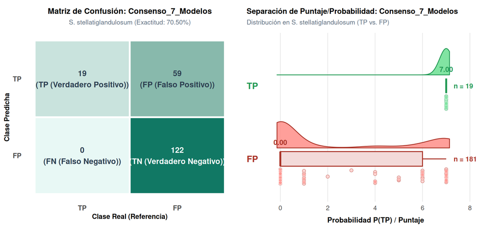

**KNN**

KNN en S. stellatiglandulosum — F1: 0.404 | ROC-AUC: 0.895 | Exactitud: 72.00% | Exactitud Bal.: 84.53% | Sensibilidad: 100.00% | Especificidad: 69.06% | Precisión: 25.33% | FDR: 74.67%

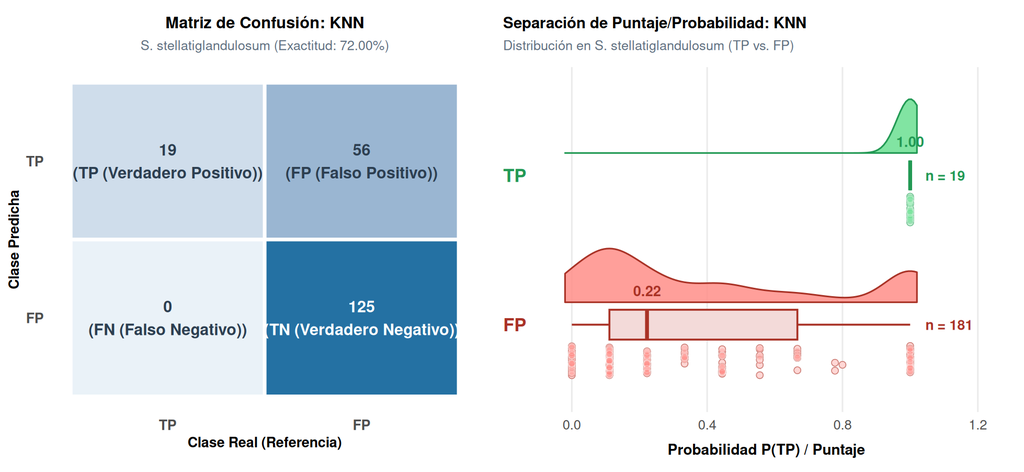

**Youden_pct_recovered**

Youden_pct_recovered en S. stellatiglandulosum — F1: 0.369 | ROC-AUC: 0.873 | Exactitud: 67.50% | Exactitud Bal.: 82.04% | Sensibilidad: 100.00% | Especificidad: 64.09% | Precisión: 22.62% | FDR: 77.38%

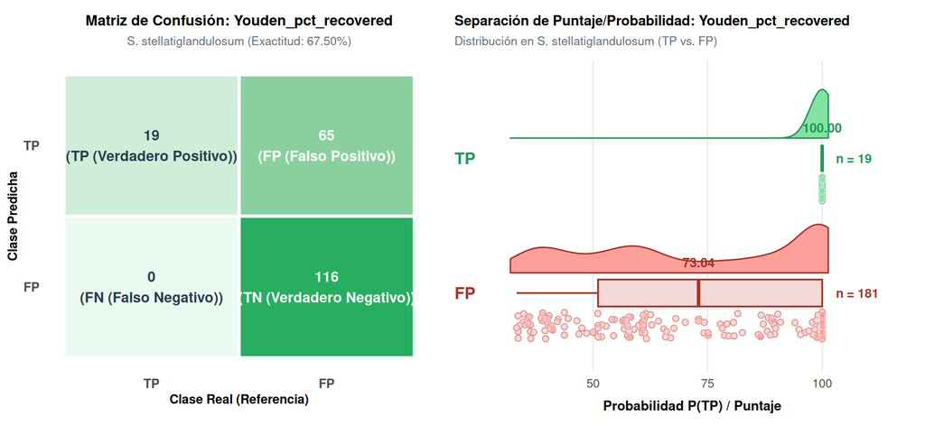

**CART**

CART en S. stellatiglandulosum — F1: 0.373 | ROC-AUC: 0.845 | Exactitud: 68.00% | Exactitud Bal.: 82.32% | Sensibilidad: 100.00% | Especificidad: 64.64% | Precisión: 22.89% | FDR: 77.11%

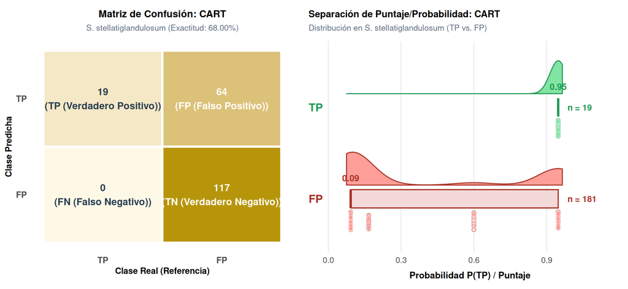

**Stacked Autoencoder - DNN**

Stacked Autoencoder - DNN en S. stellatiglandulosum — F1: 0.174 | ROC-AUC: 0.088 | Exactitud: 9.50% | Exactitud Bal.: 50.00% | Sensibilidad: 100.00% | Especificidad: 0.00% | Precisión: 9.50% | FDR: 90.50%

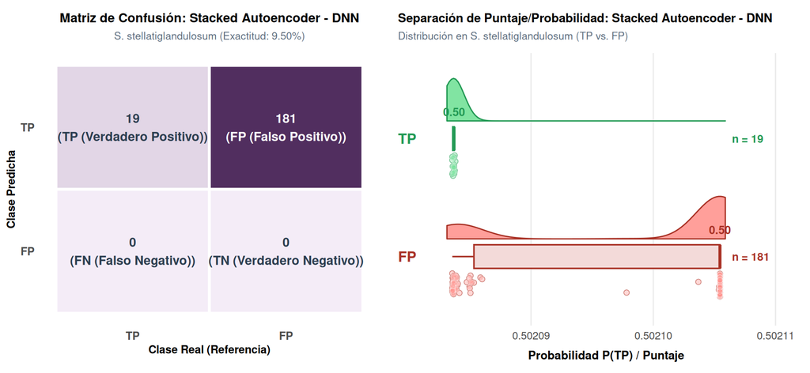

**Comparativa Multiespecie**

### 2.7 Contraste de Desempeño según Escala del Genoma (*S. torvum* vs. Receptoras)

[interactive chart not shown]

### 2.8 Tabla Consolidada Multiespecie (`transferability_all_species.tsv`)

| Especie | Escala_Genoma | Modelo | Exactitud | Exactitud_Balanceada | Sensibilidad | Especificidad | Precision | VPN | FDR | F1_Score | MCC | Kappa | ROC_AUC | TP | FP | FN | TN |
| --- | --- | --- | --- | --- | --- | --- | --- | --- | --- | --- | --- | --- | --- | --- | --- | --- | --- |
| S. torvum (Donante CV) | Escala Cromosómica | Weighted_Heuristic | 89.13 | 88.86 | 83.91 | 93.81 | 92.41 | 86.67 | 7.59 | 0.88 | 0.784 | 0.781 | 0.921 | 73 | 6 | 14 | 91 |
| S. torvum (Donante CV) | Escala Cromosómica | RandomForest | 84.24 | 83.99 | 79.31 | 88.66 | 86.25 | 82.69 | 13.75 | 0.826 | 0.685 | 0.683 | 0.902 | 69 | 11 | 18 | 86 |
| S. torvum (Donante CV) | Escala Cromosómica | GBM | 86.96 | 86.74 | 82.76 | 90.72 | 88.89 | 85.44 | 11.11 | 0.857 | 0.739 | 0.737 | 0.92 | 72 | 9 | 15 | 88 |
| S. torvum (Donante CV) | Escala Cromosómica | XGBoost | 84.78 | 84.5 | 79.31 | 89.69 | 87.34 | 82.86 | 12.66 | 0.831 | 0.696 | 0.693 | 0.92 | 69 | 10 | 18 | 87 |
| S. torvum (Donante CV) | Escala Cromosómica | SVM_Radial | 85.87 | 85.41 | 77.01 | 93.81 | 91.78 | 81.98 | 8.22 | 0.838 | 0.723 | 0.714 | 0.904 | 67 | 6 | 20 | 91 |
| S. torvum (Donante CV) | Escala Cromosómica | SVM_Lineal | 86.41 | 86.28 | 83.91 | 88.66 | 86.9 | 86 | 13.1 | 0.854 | 0.727 | 0.727 | 0.925 | 73 | 11 | 14 | 86 |
| S. torvum (Donante CV) | Escala Cromosómica | SVM_Polinomial | 87.5 | 87.14 | 80.46 | 93.81 | 92.11 | 84.26 | 7.89 | 0.859 | 0.753 | 0.748 | 0.934 | 70 | 6 | 17 | 91 |
| S. torvum (Donante CV) | Escala Cromosómica | Red_Neuronal | 87.5 | 87.31 | 83.91 | 90.72 | 89.02 | 86.27 | 10.98 | 0.864 | 0.75 | 0.749 | 0.927 | 73 | 9 | 14 | 88 |
| S. torvum (Donante CV) | Escala Cromosómica | Red_Neuronal_Bag | 87.5 | 87.26 | 82.76 | 91.75 | 90 | 85.58 | 10 | 0.862 | 0.75 | 0.748 | 0.923 | 72 | 8 | 15 | 89 |
| S. torvum (Donante CV) | Escala Cromosómica | ElasticNet | 85.33 | 85.25 | 83.91 | 86.6 | 84.88 | 85.71 | 15.12 | 0.844 | 0.706 | 0.705 | 0.93 | 73 | 13 | 14 | 84 |

[output cut: 65 more lines]

## 3 Concordancia de Número de Copias por Ortogrupo y Calibración de `--cov_threshold`

Además de evaluar la clasificación binaria a nivel de secuencia individual (`TP` vs. `FP`), se contrasta el conteo final de copias estimado por el consenso de 7 modelos ($\widehat{\text{CNV}}_{\text{OG}}$) frente al número real de copias validadas por ortogrupo ($\text{CNV}^{\text{real}}_{\text{OG}}$), empleando cuatro indicadores complementarios: correlación por rangos de Spearman ($\rho$), coeficiente Kappa cuadrático ponderado ($\kappa_w$), error cuadrático medio ($\text{RMSE}$) y tasa de concordancia exacta de copias. Paralelamente, se explora la sensibilidad empírica del parámetro `--cov_threshold` entre $30\%$ y $80\%$ para evaluar la estabilidad del umbral operativo del $50\%$.

**Resumen de Concordancia por Ortogrupo (\(\widehat{\text{CNV}}_{\text{OG}}\) vs. \(\text{CNV}^{\text{real}}_{\text{OG}}\))**

| Especie | Escala_Genoma | Umbral_Cobertura | N_Ortogrupos | Copias_Reales | Copias_Estimadas | Spearman_Rho | Spearman_P_Valor | Kappa_Cuadratico | RMSE | MAE | Sesgo_Medio | Concordancia Exacta (%) |
| --- | --- | --- | --- | --- | --- | --- | --- | --- | --- | --- | --- | --- |
| S. torvum (Donante) | Escala Cromosómica | 50 | 58 | 87 | 79 | 0.5983 | 7.04e-07 | 0.5269 | 0.871 | 0.3448 | -0.1379 | 79.31 |
| S. citrullifolium | Escala Cromosómica | 50 | 55 | 56 | 66 | 0.4653 | 3.44e-04 | 0.5506 | 0.5394 | 0.2909 | 0.1818 | 70.91 |
| S. stellatiglandulosum | Escala de Contigs | 50 | 58 | 19 | 78 | 0.0831 | 5.35e-01 | 0.0742 | 1.3834 | 1.0172 | 1.0172 | 24.14 |

**Curva de Sensibilidad de --cov_threshold (30% a 80%)**

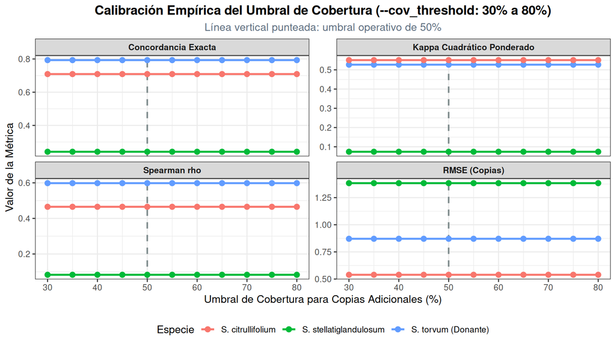

**Tabla de Calibración (30%–80%)**

| Especie | Escala_Genoma | Umbral_Cobertura | Copias_Totales_Estimadas | Copias_Principales | Homologos_Confirmados | Fragmentos_No_Contados | Pares_Multicopia | N_Ortogrupos | Copias_Reales | Concordancia_Exacta | Spearman_Rho | Spearman_P_Valor | Kappa_Cuadratico | RMSE | MAE | Sesgo_Medio |
| --- | --- | --- | --- | --- | --- | --- | --- | --- | --- | --- | --- | --- | --- | --- | --- | --- |
| S. torvum (Donante) | Escala Cromosómica | 30 | 79 | 58 | 21 | 0 | 13 | 58 | 87 | 79.31 | 0.5983 | 7.04e-07 | 0.5269 | 0.871 | 0.3448 | -0.1379 |
| S. torvum (Donante) | Escala Cromosómica | 35 | 79 | 58 | 21 | 0 | 13 | 58 | 87 | 79.31 | 0.5983 | 7.04e-07 | 0.5269 | 0.871 | 0.3448 | -0.1379 |
| S. torvum (Donante) | Escala Cromosómica | 40 | 79 | 58 | 21 | 0 | 13 | 58 | 87 | 79.31 | 0.5983 | 7.04e-07 | 0.5269 | 0.871 | 0.3448 | -0.1379 |
| S. torvum (Donante) | Escala Cromosómica | 45 | 79 | 58 | 21 | 0 | 13 | 58 | 87 | 79.31 | 0.5983 | 7.04e-07 | 0.5269 | 0.871 | 0.3448 | -0.1379 |
| S. torvum (Donante) | Escala Cromosómica | 50 | 79 | 58 | 21 | 0 | 13 | 58 | 87 | 79.31 | 0.5983 | 7.04e-07 | 0.5269 | 0.871 | 0.3448 | -0.1379 |
| S. torvum (Donante) | Escala Cromosómica | 55 | 79 | 58 | 21 | 0 | 13 | 58 | 87 | 79.31 | 0.5983 | 7.04e-07 | 0.5269 | 0.871 | 0.3448 | -0.1379 |
| S. torvum (Donante) | Escala Cromosómica | 60 | 79 | 58 | 21 | 0 | 13 | 58 | 87 | 79.31 | 0.5983 | 7.04e-07 | 0.5269 | 0.871 | 0.3448 | -0.1379 |
| S. torvum (Donante) | Escala Cromosómica | 65 | 79 | 58 | 21 | 0 | 13 | 58 | 87 | 79.31 | 0.5983 | 7.04e-07 | 0.5269 | 0.871 | 0.3448 | -0.1379 |
| S. torvum (Donante) | Escala Cromosómica | 70 | 79 | 58 | 21 | 0 | 13 | 58 | 87 | 79.31 | 0.5983 | 7.04e-07 | 0.5269 | 0.871 | 0.3448 | -0.1379 |
| S. torvum (Donante) | Escala Cromosómica | 75 | 79 | 58 | 21 | 0 | 13 | 58 | 87 | 79.31 | 0.5983 | 7.04e-07 | 0.5269 | 0.871 | 0.3448 | -0.1379 |

[output cut: 23 more lines]

**Detalle por Ortogrupo (transferability_cnv_pairs.tsv)**

| Especie | Escala_Genoma | Sample | Locus_Ortogrupo | CNV_Real | CNV_Estimado | Diferencia | Concordante |
| --- | --- | --- | --- | --- | --- | --- | --- |
| S. torvum (Donante) | Escala Cromosómica | Storvum | OG0000254 | 4 | 4 | 0 | True |
| S. torvum (Donante) | Escala Cromosómica | Storvum | OG0000261 | 6 | 2 | -4 | False |
| S. torvum (Donante) | Escala Cromosómica | Storvum | OG0000322 | 4 | 1 | -3 | False |
| S. torvum (Donante) | Escala Cromosómica | Storvum | OG0000355 | 3 | 1 | -2 | False |
| S. torvum (Donante) | Escala Cromosómica | Storvum | OG0001237 | 2 | 2 | 0 | True |
| S. torvum (Donante) | Escala Cromosómica | Storvum | OG0001399 | 1 | 2 | 1 | False |
| S. torvum (Donante) | Escala Cromosómica | Storvum | OG0001528 | 2 | 3 | 1 | False |
| S. torvum (Donante) | Escala Cromosómica | Storvum | OG0001727 | 4 | 4 | 0 | True |
| S. torvum (Donante) | Escala Cromosómica | Storvum | OG0001938 | 2 | 1 | -1 | False |
| S. torvum (Donante) | Escala Cromosómica | Storvum | OG0002043 | 2 | 2 | 0 | True |

[output cut: 161 more lines]